# Segmented signal vs whole signal

Gely Ancelin

12 mai, 2026, 15:37

# 1 Scientific problem

## 1.1 Context.

Low back pain represents the leading cause of disability worldwide. At the individual level, low back pain has substantial consequences, including activity limitations (1) as well as spinal kinematic alterations (2).

Movement smoothness has a potential to provide valuable information about sensorimotor control and to support patient assessment. It reflects the degree to which a movement is performed continuously without interruption, independently of its amplitude or duration(3). In this context, we are leading a study to evaluate **the evolution of movement smoothness in trunck flexion before and after a rehabilitation program in individuals with low back pain**. The assesment consist in performing 5 repetitions of trunck flexion while wearing an inertial measurement unit (IMU) on the lower back.

Several methods exist to evaluate movement smoothness, including the spectral arc lenght (SPARC), the log dimensionless jerk (LDLJ), the normalized number of peaks (NPP). The SPARC method has been shown to be more valid, sensitive and robust than the other methods (3,4,5). NNP as the advantage of being less computationally intensive and easier to implement.

In a previous work (6), Pearson (R=-0,75 ; p = 0,01) and Spearman (R=-0,8 ; p = 0,009) correlations showed a strong and significant negative association between SPARC and NNP when computed on a segmented movement. These results indicate a robust monotonic relationship between the two metrics.

In our study, patients are asked to perform 5 repetitions of trunck flexion. So the signal is composed of 5 flexion and 5 return from flexion (extension), **Previous studies suggested that smoothness metrics (SPARC and LDLJ) should not be computed on an entire rhythmic movements** (4). However, it is not clear how strongly this issue affects the SPARC and NNP metrics during trunk flexion assessed with IMUs in individuals with low back pain.

Computing smoothness metrics on the whole signal may present practical and methodological advantages. Whole-signal analysis simplifies the processing pipeline by avoiding manual or automated segmentation procedures, may better reflect the natural continuity of functional movement, and reduces the risk of losing potentially relevant information at the transition phases between repetitions.

## 1.2 Aim

The aim of this methodological work is to compare whole signal and segmented signal analysis for both SPARC and NNP methods in individuals with low back pain. These results will help us to determine if the SPARC and NNP metrics calculated for the whole movement can be used as a proxy for the metrics calculated for each repetition.

## 1.3 Hypothesis

We hypothesize that this work will confirm that SPARC can’t be computed on the whole signal, as it is sensitive to movement duration and structure (4). On the other hand, we expect that the NNP metric will show a stronger correlation between the whole signal and the segmented signal than the SPARC metric, due to its lower sensitivity to movement duration and structure.

# 2 Methods :

## 2.1 Participants :

10 individuals with low back pain participated in this study. The target population consisted of adults aged between 18 to 65 years with chronic low back pain persisting for more than three months. Participants were eligible for inclusion if they had a body mass index between 18 and 30 kg/m^2 and were undergoing rehabilitation in the physical and rehabilitation medicine department of Montpellier University Hospital. Patients were excluded if they had (1) experienced an episode of sciatica within the previous three months, (2) low back pain of traumatic, tumoral or infectious origin, (3) an history of spinal, pelvic or hip fracture, (4) inflammatory rheumatic disease, (5) prior spinal fusion, (6) severe scoliosis, (7) inability to provide informed consent or legal protection status, (8) lack of affiliation with a social security system, (9) deprived of liberty by judicial or administrative decision, (10) concurrent participation in another research study with an ongoing exclusion period, (11) pregnancy or breastfeeding

## 2.2 Data collection :

Patients were equipped with Xsens inertial sensors (Awinda) placed on the head, T8, L1, L3 and S1, with a sampling frequency of 60 Hz. Participants completed a standardized task including five repetitions each of maximal lumbar flexion and trunk rotation to the left and right, while standing with feet shoulder-width apart, knees extended. Each assessment lasted approximately 15 minutes.

## 2.3 Outcome mesured :

Movement smoothness was evaluated based on the velocity profile given by the gyroscope. It is quantified using two metrics : SPARC and NNP. These metrics are described in detail in the Python_project

$$SPARC = - ∫ | \sqrt(dV(ω)/dω) dω
|$$

Where V(ω) is the Fourier magnitude spectrum of the velocity profile and ω is the angular frequency.

$$NNP = \frac{\text{number of peaks in the
velocity profile}}{\text{total duration of the movement}}$$

# 3 Python project : data analysis

## 3.1 aim

the aim of the python project is to extract the velocity profile from the gyroscope data, segment the movement into individual repetitions of flexion and extension and calculate the SPARC and NNP metrics for each repetition and for the whole movement. These computations were performed using Python, and the results are stored in an Excel file “results_all.xlsx” that will be used in this Rstudio project.

# 4 Rstudio project

The aim of this code is to load the SPARC and NNP for the whole signal and segmented signal computed in the Python_project and look for a relationship.

## 4.1 Data organisation

### 4.1.1 File name

**results_all.xlsx** These data are the results of the Python_project, in which we computed the SPARC and NNP for the whole signal and segmented signal for 10 individuals with low back pain performing a flexion-extension task.

## 4.2 Notebook organisation

In this notebook, we will perform the following steps :

1. Import libraries
2. Load and visualize the data computed in the Python project
3. Create a new dataframe with the mean SPARC and NNP for the segmented signal for each participant
4. Plot the relationship between mean_NNP_flexion/NNP and mean_SPARC_flexion/SPARC
5. Compute the Bland-Altman test for NNP and SPARC to evaluate the agreement between the whole signal and the segmented signal for both metrics.

### 4.2.1 Import libraries

```r
# import libraries to read excel and compute a plot
library(readxl)
library(ggplot2)
library(ggpubr)
library(dplyr)
library(stringr)
```

### 4.2.2 Load and visualise the data computed in the Python project

```r
# From data, import "results_repetition.xlsx"
data_subject <- read_excel("data/results_all.xlsx")
data_subject
```

| Signal name | SPARC | NNP | mean_SPARC_flexion | mean_NNP_flexion |
| --- | --- | --- | --- | --- |
| FlexionDos_001_av | -2.407429 | 3.298969 | -1.590033 | 3.606448 |
| FlexionDos_002_av | -2.604983 | 4.836795 | -1.599476 | 4.456060 |
| FlexionDos_003_av | -3.752114 | 4.608295 | -1.663036 | 5.254725 |
| FlexionDos_004_av | -2.643519 | 1.632653 | -1.254217 | 1.638562 |
| FlexionDos_005_av | -3.823350 | 6.502717 | -2.666419 | 7.158464 |
| FlexionDos_006_av | -3.111388 | 3.435996 | -1.404137 | 3.252055 |
| FlexionDos_007_av | -2.585121 | 1.462424 | -1.366907 | 1.426816 |
| FlexionDos_008_av | -2.854574 | 4.536510 | -1.648584 | 4.333151 |
| FlexionDos_009_av | -2.734137 | 3.080214 | -1.351780 | 3.075312 |
| FlexionDos_010_av | -2.817231 | 4.664879 | -1.654471 | 4.990489 |

## 4.3 Visualisation

### 4.3.1 plot NNP as a function of NNP_flexion

This plot shows the relationship between NNP_flexion and NNP.

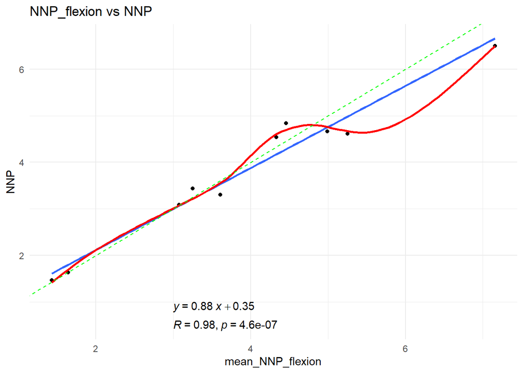

```r
# Plot NNP_flexion as a function of NNP
ggplot(data_subject, aes(x = mean_NNP_flexion, y = NNP)) +
  geom_point() +
  geom_smooth(method = "lm", se = FALSE) +
  geom_smooth(method = "loess", se = FALSE, color = "red") +
  geom_abline(slope = 1, intercept = 0, color = "green", linetype = "dashed") +
  # add the equation and the R-squared value to the plot
  stat_regline_equation(label.x = 3, label.y = 0.9) +
  stat_cor(method = "pearson", label.x = 3, label.y = 0.5) +
  labs(title = "NNP_flexion vs NNP",
       x = "mean_NNP_flexion",
       y = "NNP") +
  theme_minimal()
```

**Observation** : There is a positive correlation between NNP_flexion and NNP. Le loess fit (red line) and the linear fit (blue line) are quite similar, indicating that the relationship between NNP_flexion and NNP is approximately linear.

**Results**: the slope value (0.88) indicates that for every unit increase the segmented signal, there is an expected increase of 0.88 units in the whole signal. The intercept value (0.35) suggests that when NNP_flexion is zero, NNP is expected to be 0.35.

**Interpretation** This suggests that the whole signal and the segmented signal provide similar information about movement smoothness when using the NNP metric.

### 4.3.2 plot SPARC_flexion as a function of SPARC

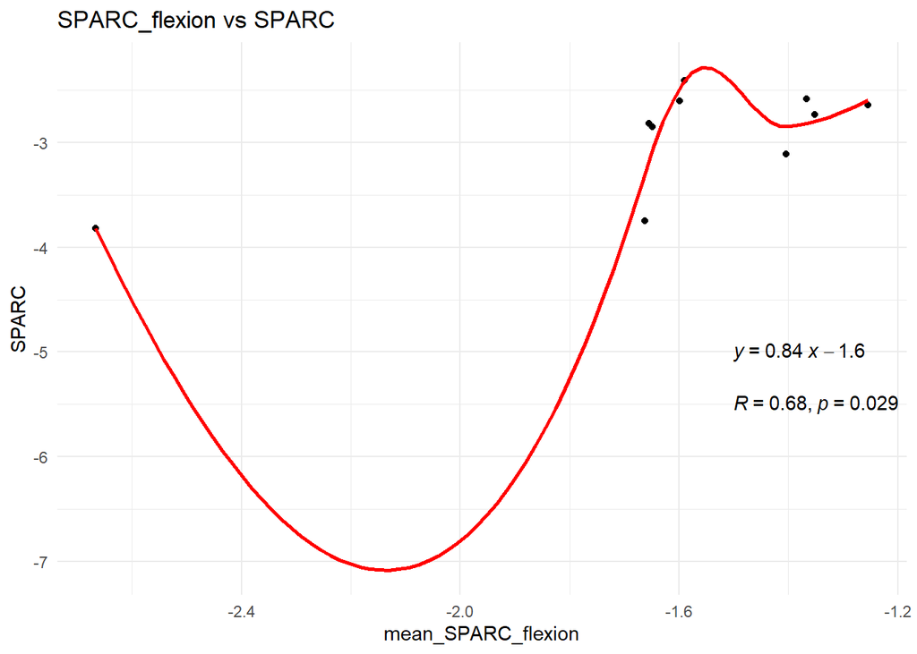

```r
# Plot SPARC_flexion as a function of SPARC
ggplot(data_subject, aes(x = mean_SPARC_flexion, y = SPARC)) +
  geom_point() +
  #geom_smooth(method = "lm", se = FALSE) +
  geom_smooth(method = "loess", se = FALSE, color = "red") +
  #geom_abline(slope = 1, intercept = 0, color = "green", linetype = "dashed") +
  stat_regline_equation(label.x = -1.5, label.y = -5) +
  stat_cor(method = "pearson", label.x = -1.5, label.y = - 5.5) +
  labs(title = "SPARC_flexion vs SPARC",
       x = "mean_SPARC_flexion",
       y = "SPARC") +
  theme_minimal()
```

**Observation** : No clear linear relationship between SPARC_flexion and SPARC. The loess fit (red line) shows a non-linear pattern.

**Results** : The slope value (0.84) indicates that for every unit increase in SPARC_flexion, there is an expected increase of 0.84 units in SPARC. The intercept value (-1.6) suggests that when SPARC_flexion is zero, SPARC is expected to be -1.6.

**Interpretation** : This suggests that the whole signal and the segmented signal provide different information about movement smoothness when using the SPARC metric.

This difference might be due to the fact that SPARC is more sensitive to movement duration and structure than NNP, which can lead to different values for the whole signal and the segmented signal.

## 4.4 Bland-Altman test

Correlation quantifies the degree to which two variables are linearly related, but it does not provide information about the agreement between the two methods. The bland-Altman test is a method to evaluate the agreement between two methods of measurement (7). It consists in plotting the difference between the two methods against the mean of the two methods, and calculating the bias (mean difference) and the limits of agreement (bias ± 1.96 * standard deviation of the differences). The difference has to be normally distributed, that’s the reason whya shapiro wilk test is performed (7).

$$difference = whole - segmented$$
Result of the Bland-Altman test will be presented in a table with the following columns :

bias : mean difference between the whole signal and the segmented signal. This value indicates if there is a systematic difference between the two methods. A bias close to zero indicates good agreement between the two methods, while a bias different from zero indicates a systematic difference.

$$bias = mean(difference)$$
Upper : upper limit of agreement (bias + 1.96 * sd). This value indicates the upper bound of the range in which most of the differences between the two methods are expected to lie. If the upper limit is close to zero, it suggests that there is good agreement between the two methods for high values.

$$\text{upper limit of agreement} = bias +
1.96 * sd$$
lower : lower limit of agreement (bias - 1.96 * sd). This value indicates the lower bound of the range in which most of the differences between the two methods are expected to lie. If the lower limit is close to zero, it suggests that there is good agreement between the two methods for low values.

$$\text{lower limit of agreement} = bias -
1.96 * sd$$

perc_bias : percentage bias (bias / mean of the two methods) * 100. This value indicates the bias as a percentage of the mean of the two methods. A smaller percentage bias indicates better agreement between the two methods.

$$\text{percentage bias} = \left(
\frac{bias}{\text{mean of the two methods}} \right) * 100$$

The result is a graph in which the x-axis represents the mean of the two methods and the y-axis represents the difference between the two methods. The bias is represented by a horizontal line, and the limits of agreement are represented by two dashed lines. 95% of the points should lie within the limits of agreement if the two methods are in good agreement (7). The interpretation of this graph relies on the line of equality that should be within the limits of agreement, and on the limit of acceptable difference that should be defined a priori based on relevant criteria. (7)

### 4.4.1 Bland-Altman - NNP

```r
# Compute the Bland-Altman test

data_subject$mean_NNP <- (data_subject$NNP + data_subject$mean_NNP_flexion) / 2
data_subject$diff_NNP <- data_subject$NNP - data_subject$mean_NNP_flexion

# Shapiro wilk test to test the normal distribution of the differences
shapiro.test(data_subject$diff_NNP)
```

```
##
##  Shapiro-Wilk normality test
##
## data:  data_subject$diff_NNP
## W = 0.92205, p-value = 0.3744
```

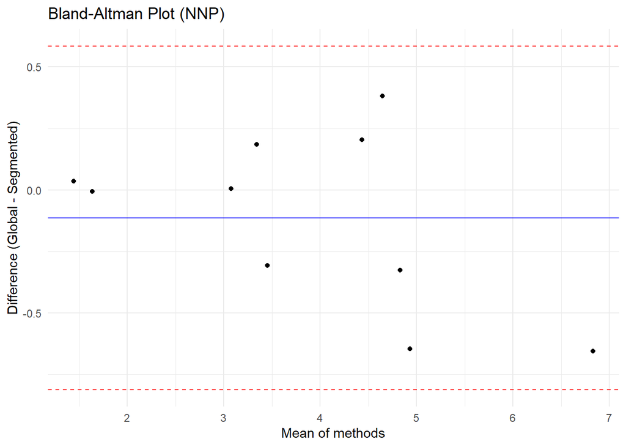

```r
bias_NNP <- mean(data_subject$diff_NNP, na.rm = TRUE)
sd_NNP <- sd(data_subject$diff_NNP, na.rm = TRUE)

upper_NNP <- bias_NNP + 1.96 * sd_NNP
lower_NNP <- bias_NNP - 1.96 * sd_NNP

# Plot
ggplot(data_subject, aes(x = mean_NNP, y = diff_NNP)) +
  geom_point() +
  geom_hline(yintercept = bias_NNP, color = "blue") +
  geom_hline(yintercept = upper_NNP, linetype = "dashed", color = "red") +
  geom_hline(yintercept = lower_NNP, linetype = "dashed", color = "red") +
  labs(title = "Bland-Altman Plot (NNP)",
       x = "Mean of methods",
       y = "Difference (Global - Segmented)") +
  theme_minimal()
```

**Results** The Shapiro-wilk test indicates that the differences between the two methods did not significantly deviate from normality (W = 0.922, p = 0.374). Therefore, the assumption of normality was considered satisfied.

The Bland–Altman plot showed a small mean bias between the two methods, with most observations lying within the limits of agreement. The Bland–Altman plot suggested heteroscedasticity, as the variability of the differences increased with measurement magnitude.

### 4.4.2 Bland-Altman test - SPARC

```r
# Compute the Bland-Altman test
data_subject$mean_SPARC <- (data_subject$SPARC + data_subject$mean_SPARC_flexion) / 2
data_subject$diff_SPARC <- data_subject$SPARC - data_subject$mean_SPARC_flexion

# Shapiro wilk test to test the normal distribution of the differences
shapiro.test(data_subject$diff_SPARC)
```

```
##
##  Shapiro-Wilk normality test
##
## data:  data_subject$diff_SPARC
## W = 0.91574, p-value = 0.3228
```

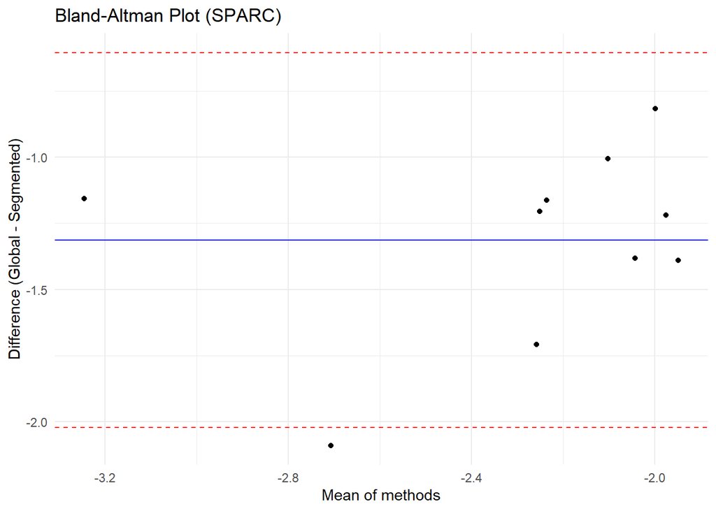

```r
bias_SPARC <- mean(data_subject$diff_SPARC, na.rm = TRUE)
sd_SPARC <- sd(data_subject$diff_SPARC, na.rm = TRUE)

upper_SPARC <- bias_SPARC + 1.96 * sd_SPARC
lower_SPARC <- bias_SPARC - 1.96 * sd_SPARC

# Plot
ggplot(data_subject, aes(x = mean_SPARC, y = diff_SPARC)) +
  geom_point() +
  geom_hline(yintercept = bias_SPARC, color = "blue") +
  geom_hline(yintercept = upper_SPARC, linetype = "dashed", color = "red") +
  geom_hline(yintercept = lower_SPARC, linetype = "dashed", color = "red") +
  labs(title = "Bland-Altman Plot (SPARC)",
       x = "Mean of methods",
       y = "Difference (Global - Segmented)") +
  theme_minimal()
```

The plot showed a sloped pattern rather than a random distribution of points, indicating that the agreement between methods may depend on the magnitude of the measurements.

```r
# % bias NNP
mean_NNP_all <- mean(c(data_subject$NNP, data_subject$mean_NNP_flexion), na.rm = TRUE)
perc_bias_NNP <- (bias_NNP / mean_NNP_all) * 100

# % bias SPARC
mean_SPARC_all <- mean(c(data_subject$SPARC, data_subject$mean_SPARC_flexion), na.rm = TRUE)
perc_bias_SPARC <- (bias_SPARC / mean_SPARC_all) * 100

ba_table <- data.frame(
  methode = c("NNP", "SPARC"),
  bias = c(bias_NNP, bias_SPARC),
  sd = c(sd_NNP, sd_SPARC),
  lower = c(lower_NNP, lower_SPARC),
  upper = c(upper_NNP, upper_SPARC),
  perc_bias = c(perc_bias_NNP, perc_bias_SPARC)
  )

ba_table
```

| methode | bias | sd | lower | upper | perc_bias |
| --- | --- | --- | --- | --- | --- |
| NNP | -0.1132631 | 0.3561571 | -0.811331 | 0.5848048 | -2.93232 |
| SPARC | -1.3134787 | 0.3614632 | -2.021947 | -0.6050108 | 57.69361 |

The best way to interpret these results would be to define a priori the limit of maximal acceptable difference, based on relevant criteria. Unfortunately, as our method is rarely used, mostly in a trunk flexion movement, there is no consensus about this limit. However, we can look at the percentage bias to have an idea of the agreement between the two methods.

This result is consistent with the correlation results and support our hypothesis.

## 4.5 Discussion :

The bias for NNP is low (-2,9%). This may be explained by the inclusion of resting periods in the whole signal, which could reduce the number of detected peaks compared to the segmented signal focusing exclusively on the flexion phase. In addition, the whole signal includes both concentric and eccentric phases, which may involve different motor control strategies and may therefore influence NNP values.

The bias is relatively low and might be acceptable, depending on the context and the criteria for maxiaml acceptable difference.However the heteroscedasticity observed in the Bland-Altman plot for NNP suggests that the agreement between the whole signal and the segmented signal may depend on the magnitude of the measurements.

## 4.6 Perspective :

Future works should focus on determine a limit of maximal acceptable difference for both NNP and SPARC. This would allow us to better interpret the results of the Bland-Altman test and to determine if the agreement between the whole signal and the segmented signal is acceptable for clinical use.

## 4.7 Conclusion

In the context of trunk flexion in individuals with low back pain before and after rehabilitation, these results suggest that SPARC should be interpreted cautiously when computed on whole signals. For NNP, the agreement appears acceptable, although further analysis is needed to confirm the impact of heteroscedasticity.

# 5 References :

1. Hartvigsen J, Hancock MJ, Kongsted A, Louw Q, Ferreira ML, Genevay S, et al. What low back pain is and why we need to pay attention. Lancet Lond Engl. 9 juin 2018;391(10137):2356‑67
2. Errabity A, Calmels P, Han WS, Bonnaire R, Pannetier R, Convert R, et al. The effect of low back pain on spine kinematics: A systematic review and meta-analysis. Clin Biomech. août 2023;108:106070
3. Balasubramanian S, Melendez-Calderon A, Roby-Brami A, Burdet E. On the analysis of movement smoothness. J Neuroengineering Rehabil. 9 déc 2015;12:112
4. Balasubramanian S, Melendez-Calderon A, Roby-Brami A, Burdet E. On the analysis of movement smoothness. J Neuroeng Rehabil. 9 déc 2015;12:112. doi:10.1186/s12984-015-0090-9 PubMed PMID: 26651329; PubMed Central PMCID: PMC4674971.
5. Melendez-Calderon A, Shirota C, Balasubramanian S. Estimating Movement Smoothness From Inertial Measurement Units. Front Bioeng Biotechnol. 14 janv 2021;8:558771. doi:10.3389/fbioe.2020.558771
6. https://github.com/ancelingely/Projet_R_Python_M2_REHAB.git
7. Giavarina D. Understanding Bland Altman analysis. Biochem Med. 2015;25(2):141‑51. doi:10.11613/BM.2015.015